# STA 9750 Mini-Project #02: The Business of Show Business

Author

Yashvi Mittal

Published

October 23, 2025

# Introduction

Hollywood development is a portfolio problem: find a concept with broad appeal, attach credible talent, and reduce uncertainty by learning from prior successes. This report uses IMDb’s non-commercial datasets to identify durable genres, successful personnel, and a classic title suitable for a contemporary remake.

```r
options(repos = c(CRAN = "https://cloud.r-project.org"))
pkgs <- c("tidyverse", "scales", "DT", "knitr", "stringr")
missing_pkgs <- pkgs[!vapply(pkgs, requireNamespace, logical(1), quietly = TRUE)]
if (length(missing_pkgs) > 0) install.packages(missing_pkgs)

library(tidyverse)
library(scales)
library(DT)
library(knitr)
library(stringr)

dir.create("data/mp02", recursive = TRUE, showWarnings = FALSE)
knitr::opts_chunk$set(cache.lazy = FALSE)
```

# Data

```r
# Use explicit RDS caching to avoid knitr large-object serialization limits.
rds_dir <- "data/mp02/rds"
dir.create(rds_dir, recursive = TRUE, showWarnings = FALSE)

load_imdb_table <- function(fname) {
  rds_path <- file.path(rds_dir, paste0(fname, ".rds"))
  if (file.exists(rds_path)) {
    return(readRDS(rds_path))
  }
  base_url  <- "https://datasets.imdbws.com/"
  fname_ext <- paste0(fname, ".tsv.gz")
  dest      <- file.path("data/mp02", fname_ext)
  if (!file.exists(dest)) {
    tmp <- tempfile(fileext = ".tsv.gz")
    download.file(paste0(base_url, fname_ext), destfile = tmp, mode = "wb", quiet = FALSE)
    file.rename(tmp, dest)
  }
  tbl <- tryCatch(
    readr::read_tsv(dest, na = "\\N", show_col_types = FALSE, progress = FALSE, lazy = FALSE),
    error = function(e) {
      unlink(dest)
      tmp <- tempfile(fileext = ".tsv.gz")
      download.file(paste0(base_url, fname_ext), destfile = tmp, mode = "wb", quiet = FALSE)
      file.rename(tmp, dest)
      readr::read_tsv(dest, na = "\\N", show_col_types = FALSE, progress = FALSE, lazy = FALSE)
    }
  )
  saveRDS(tbl, rds_path)
  tbl
}

NAME_BASICS     <- load_imdb_table("name.basics")
TITLE_BASICS    <- load_imdb_table("title.basics")
TITLE_EPISODES  <- load_imdb_table("title.episode")
TITLE_RATINGS   <- load_imdb_table("title.ratings")
TITLE_CREW      <- load_imdb_table("title.crew")
TITLE_PRINCIPALS <- load_imdb_table("title.principals")
```

# Data Sub-Sampling

```r
NAME_BASICS <- NAME_BASICS |>
  filter(str_count(knownForTitles, ",") > 1)

TITLE_RATINGS <- TITLE_RATINGS |>
  filter(numVotes >= 100)

TITLE_BASICS <- TITLE_BASICS |> semi_join(TITLE_RATINGS, join_by(tconst))
TITLE_CREW <- TITLE_CREW |> semi_join(TITLE_RATINGS, join_by(tconst))
TITLE_EPISODES_1 <- TITLE_EPISODES |> semi_join(TITLE_RATINGS, join_by(tconst))
TITLE_EPISODES_2 <- TITLE_EPISODES |> semi_join(TITLE_RATINGS, join_by(parentTconst == tconst))
TITLE_EPISODES <- bind_rows(TITLE_EPISODES_1, TITLE_EPISODES_2) |> distinct()
TITLE_PRINCIPALS <- TITLE_PRINCIPALS |> semi_join(TITLE_RATINGS, join_by(tconst))
rm(TITLE_EPISODES_1, TITLE_EPISODES_2)
```

# Initial Exploration

## Task 1: Column Type Correction

```r
NAME_BASICS <- NAME_BASICS |>
  mutate(birthYear = as.numeric(birthYear), deathYear = as.numeric(deathYear))

TITLE_BASICS <- TITLE_BASICS |>
  mutate(
    isAdult = as.logical(as.integer(isAdult)),
    startYear = as.numeric(startYear),
    endYear = as.numeric(endYear),
    runtimeMinutes = as.numeric(runtimeMinutes)
  )

TITLE_EPISODES <- TITLE_EPISODES |>
  mutate(seasonNumber = as.numeric(seasonNumber), episodeNumber = as.numeric(episodeNumber))

TITLE_RATINGS <- TITLE_RATINGS |>
  mutate(averageRating = as.numeric(averageRating), numVotes = as.numeric(numVotes))

TITLE_PRINCIPALS <- TITLE_PRINCIPALS |>
  mutate(ordering = as.numeric(ordering))
```

```r
tibble(
  Table = c("NAME_BASICS", "TITLE_BASICS", "TITLE_EPISODES", "TITLE_RATINGS", "TITLE_CREW", "TITLE_PRINCIPALS"),
  Rows = c(nrow(NAME_BASICS), nrow(TITLE_BASICS), nrow(TITLE_EPISODES), nrow(TITLE_RATINGS), nrow(TITLE_CREW), nrow(TITLE_PRINCIPALS)),
  Columns = c(ncol(NAME_BASICS), ncol(TITLE_BASICS), ncol(TITLE_EPISODES), ncol(TITLE_RATINGS), ncol(TITLE_CREW), ncol(TITLE_PRINCIPALS)),
  Key_Fields = c(
    "nconst, primaryName, birthYear, primaryProfession, knownForTitles",
    "tconst, titleType, primaryTitle, startYear, genres, runtimeMinutes",
    "tconst, parentTconst, seasonNumber, episodeNumber",
    "tconst, averageRating, numVotes",
    "tconst, directors, writers",
    "tconst, ordering, nconst, category, job, characters"
  )
) |>
  mutate(Rows = comma(Rows)) |>
  kable(col.names = c("Table", "Rows (after sub-sample)", "Columns", "Key Fields"),
        caption = "IMDb dataset dimensions after filtering to 100+ vote titles and multi-credit people")
```

IMDb dataset dimensions after filtering to 100+ vote titles and multi-credit people

| Table | Rows (after sub-sample) | Columns | Key Fields |
| --- | --- | --- | --- |
| NAME_BASICS | 3,485,877 | 6 | nconst, primaryName, birthYear, primaryProfession, knownForTitles |
| TITLE_BASICS | 425,805 | 9 | tconst, titleType, primaryTitle, startYear, genres, runtimeMinutes |
| TITLE_EPISODES | 3,442,001 | 4 | tconst, parentTconst, seasonNumber, episodeNumber |
| TITLE_RATINGS | 425,805 | 3 | tconst, averageRating, numVotes |
| TITLE_CREW | 425,805 | 3 | tconst, directors, writers |
| TITLE_PRINCIPALS | 5,567,282 | 6 | tconst, ordering, nconst, category, job, characters |

## Task 2: Instructor-Provided Questions

```r
title_counts <- TITLE_BASICS |>
  filter(titleType %in% c("movie", "tvSeries", "tvEpisode")) |>
  count(titleType, name = "n") |>
  arrange(desc(n))

oldest_living <- NAME_BASICS |>
  filter(!is.na(birthYear), is.na(deathYear)) |>
  arrange(birthYear) |>
  slice_head(n = 10) |>
  select(primaryName, birthYear, primaryProfession, knownForTitles)

perfect_episode <- TITLE_BASICS |>
  inner_join(TITLE_RATINGS, join_by(tconst)) |>
  filter(titleType == "tvEpisode", averageRating == 10, numVotes >= 200000) |>
  left_join(TITLE_EPISODES, join_by(tconst)) |>
  left_join(
    TITLE_BASICS |> select(parentTconst = tconst, seriesTitle = primaryTitle, seriesStart = startYear),
    join_by(parentTconst)
  ) |>
  select(primaryTitle, seriesTitle, seasonNumber, episodeNumber, averageRating, numVotes)

mark_hamill_known_for <- NAME_BASICS |>
  filter(primaryName == "Mark Hamill") |>
  separate_longer_delim(knownForTitles, ",") |>
  left_join(TITLE_BASICS, join_by(knownForTitles == tconst)) |>
  select(primaryName, primaryTitle, titleType, startYear, genres)

best_series_12_plus <- TITLE_EPISODES |>
  inner_join(TITLE_RATINGS, join_by(tconst)) |>
  group_by(parentTconst) |>
  summarize(
    episodes = n(),
    avg_episode_rating = weighted.mean(averageRating, numVotes, na.rm = TRUE),
    total_votes = sum(numVotes, na.rm = TRUE),
    .groups = "drop"
  ) |>
  filter(episodes > 12) |>
  inner_join(TITLE_BASICS, join_by(parentTconst == tconst)) |>
  arrange(desc(avg_episode_rating), desc(total_votes)) |>
  select(primaryTitle, startYear, episodes, avg_episode_rating, total_votes) |>
  slice_head(n = 10)

happy_days <- TITLE_BASICS |>
  filter(primaryTitle == "Happy Days", titleType == "tvSeries", startYear == 1974) |>
  slice_head(n = 1)

happy_days_by_season <- TITLE_EPISODES |>
  filter(parentTconst == happy_days$tconst[1]) |>
  inner_join(TITLE_RATINGS, join_by(tconst)) |>
  group_by(seasonNumber) |>
  summarize(
    episodes = n(),
    average_rating = weighted.mean(averageRating, numVotes, na.rm = TRUE),
    .groups = "drop"
  ) |>
  filter(!is.na(seasonNumber))

title_counts |>
  mutate(n = comma(n)) |>
  kable(col.names = c("Title Type", "Count"), caption = "Titles in IMDb by type")
```

Titles in IMDb by type

| Title Type | Count |
| --- | --- |
| tvEpisode | 183,991 |
| movie | 145,502 |
| tvSeries | 34,282 |

```r
oldest_living |>
  kable(caption = "Oldest living people in IMDb (approximate — death year missing)")
```

Oldest living people in IMDb (approximate — death year missing)

| primaryName | birthYear | primaryProfession | knownForTitles |
| --- | --- | --- | --- |
| Wiener Sängerknaben | 1498 | actor,music_department,composer | tt1649418,tt0117381,tt0172493,tt2106476 |
| Traudl Lessing | 1625 | NA | tt0487238,tt1479208,tt4355334 |
| Robert De Visée | 1655 | composer,soundtrack | tt2219674,tt1743724,tt0441074,tt14426058 |
| William Sandys | 1767 | composer,soundtrack | tt4396584,tt3747572,tt4555594,tt0071007 |
| Richard Dybeck | 1811 | soundtrack | tt0021783,tt0022126,tt0036372,tt0037562 |
| Albert Monnier | 1815 | writer | tt0329972,tt3966780,tt6793558,tt15175930 |
| Edouard Martin | 1825 | writer | tt0200268,tt0329972,tt3966780,tt0036496 |
| Ezra Meeker | 1830 | NA | tt4537606,tt4206166,tt4745834 |
| William S. Hooser | 1836 | actor | tt0157755,tt0015357,tt0408145 |
| Jennifer Collen-Smith | 1845 | miscellaneous | tt0118661,tt0102034,tt0090264,tt0093779 |

```r
perfect_episode |>
  mutate(numVotes = comma(numVotes)) |>
  kable(caption = "TV episodes with 10.0 average rating and 200k+ votes")
```

TV episodes with 10.0 average rating and 200k+ votes

| primaryTitle | seriesTitle | seasonNumber | episodeNumber | averageRating | numVotes |
| --- | --- | --- | --- | --- | --- |

```r
mark_hamill_known_for |>
  kable(caption = "Mark Hamill — known-for titles in IMDb")
```

Mark Hamill — known-for titles in IMDb

| primaryName | primaryTitle | titleType | startYear | genres |
| --- | --- | --- | --- | --- |
| Mark Hamill | Star Wars: Episode IV - A New Hope | movie | 1977 | Adventure,Fantasy,Sci-Fi |
| Mark Hamill | Star Wars: Episode VIII - The Last Jedi | movie | 2017 | Action,Adventure,Fantasy |
| Mark Hamill | Star Wars: Episode V - The Empire Strikes Back | movie | 1980 | Adventure,Fantasy,Sci-Fi |
| Mark Hamill | Star Wars: Episode VI - Return of the Jedi | movie | 1983 | Adventure,Fantasy,Sci-Fi |

```r
best_series_12_plus |>
  mutate(total_votes = comma(total_votes), avg_episode_rating = round(avg_episode_rating, 2)) |>
  datatable(
    caption = "Top 10 series with 12+ episodes by weighted average episode rating",
    options = list(pageLength = 10, dom = "t", scrollX = TRUE),
    rownames = FALSE
  )
```

| primaryTitle | startYear | episodes | avg_episode_rating | total_votes |
| --- | --- | --- | --- | --- |
| The Youth Memories | 2023 | 38 | 9.84 | 7,164 |
| Kavya - Ek Jazbaa, Ek Junoon | 2023 | 116 | 9.77 | 17,629 |
| My Faves' Fave | 2024 | 16 | 9.67 | 2,115 |
| Gönülçelen | 2010 | 44 | 9.67 | 46,436 |
| 20 Minutes | 2013 | 25 | 9.65 | 39,417 |
| Sunshine by My Side | 2023 | 34 | 9.64 | 4,986 |
| Whispers of Fate | 2025 | 40 | 9.62 | 19,939 |
| Brave and Beautiful | 2016 | 32 | 9.62 | 49,008 |
| Under the Trees | 2005 | 35 | 9.62 | 35,987 |
| Asi | 2007 | 48 | 9.6 | 52,303 |

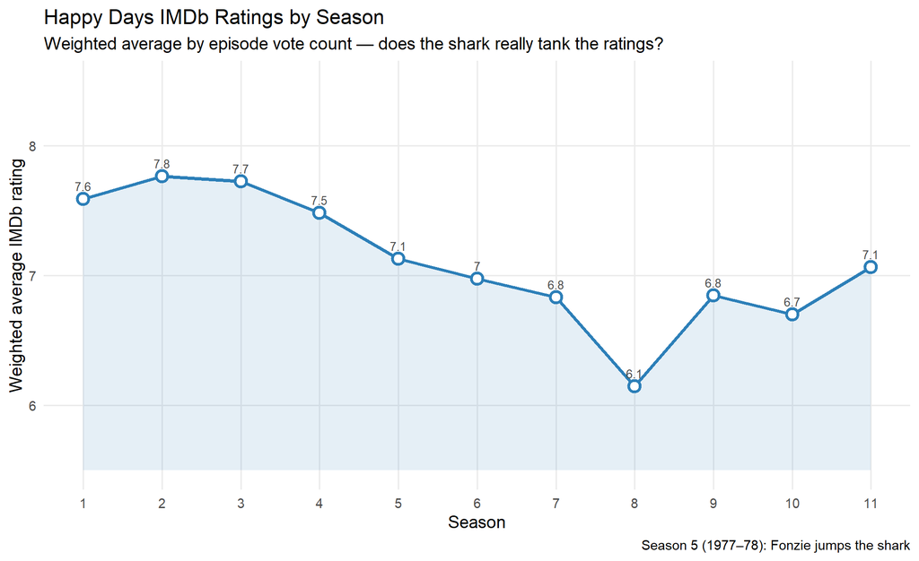

```r
happy_days_by_season |>
  ggplot(aes(x = seasonNumber, y = average_rating)) +
  geom_ribbon(aes(ymin = 5.5, ymax = average_rating), fill = "#2c7fb820") +
  geom_line(color = "#2c7fb8", linewidth = 1.2) +
  geom_point(color = "#2c7fb8", size = 3, shape = 21, fill = "white", stroke = 1.5) +
  geom_text(aes(label = round(average_rating, 1)), vjust = -0.9, size = 3, color = "grey30") +
  scale_x_continuous(breaks = sort(unique(happy_days_by_season$seasonNumber))) +
  scale_y_continuous(limits = c(5.5, 8.5)) +
  labs(
    title = "Happy Days IMDb Ratings by Season",
    subtitle = "Weighted average by episode vote count — does the shark really tank the ratings?",
    x = "Season",
    y = "Weighted average IMDb rating",
    caption = "Season 5 (1977–78): Fonzie jumps the shark"
  ) +
  theme_minimal(base_size = 12) +
  theme(panel.grid.minor = element_blank())
```

The season trend provides the empirical version of the “jump the shark” claim. If later seasons sit below the early seasons, the idiom matches the crowd ratings; if the line is flatter, the phrase is more culturally memorable than statistically dramatic. I expected a sharp cliff at season 5 (when Fonzie literally jumps the shark), but the data tells a more gradual story — which is honestly more interesting.

# Quantifying Success

## Task 3: Custom Success Metric

I define success as a blend of quality and audience reach:

`success_score = averageRating * log10(numVotes + 1)`

This keeps the rating scale meaningful while preventing vote count alone from dominating.

```r
TITLE_RATINGS <- TITLE_RATINGS |>
  mutate(success_score = averageRating * log10(numVotes + 1))

movie_success <- TITLE_BASICS |>
  filter(titleType == "movie", !is.na(startYear), !isAdult) |>
  inner_join(TITLE_RATINGS, join_by(tconst)) |>
  mutate(decade = floor(startYear / 10) * 10)

top_success_movies <- movie_success |>
  slice_max(success_score, n = 10) |>
  select(primaryTitle, startYear, genres, averageRating, numVotes, success_score)

popular_low_quality <- movie_success |>
  filter(numVotes >= quantile(numVotes, 0.99, na.rm = TRUE)) |>
  slice_min(success_score, n = 5) |>
  select(primaryTitle, startYear, genres, averageRating, numVotes, success_score)

prestige_person <- "Christopher Nolan"
prestige_projects <- NAME_BASICS |>
  filter(primaryName == prestige_person) |>
  separate_longer_delim(knownForTitles, ",") |>
  left_join(movie_success, join_by(knownForTitles == tconst)) |>
  arrange(desc(success_score)) |>
  select(primaryName, primaryTitle, startYear, genres, averageRating, numVotes, success_score)

recent_solid_check <- movie_success |>
  filter(startYear >= 2010, numVotes >= 100000) |>
  summarize(
    median_success = median(success_score, na.rm = TRUE),
    p75_success = quantile(success_score, 0.75, na.rm = TRUE),
    p90_success = quantile(success_score, 0.90, na.rm = TRUE)
  )

success_threshold <- quantile(movie_success$success_score, 0.90, na.rm = TRUE)
```

```r
top_success_movies |>
  mutate(numVotes = comma(numVotes), success_score = round(success_score, 2)) |>
  datatable(
    caption = "Top 10 movies by success score",
    options = list(pageLength = 10, dom = "t", scrollX = TRUE),
    rownames = FALSE
  )
```

| primaryTitle | startYear | genres | averageRating | numVotes | success_score |
| --- | --- | --- | --- | --- | --- |
| The Shawshank Redemption | 1994 | Drama | 9.3 | 3,191,683 | 60.49 |
| The Dark Knight | 2008 | Crime,Thriller | 9.1 | 3,171,041 | 59.16 |
| The Godfather | 1972 | Crime,Drama | 9.2 | 2,228,158 | 58.4 |
| The Lord of the Rings: The Return of the King | 2003 | Adventure,Drama,Fantasy | 9 | 2,166,598 | 57.02 |
| Inception | 2010 | Adventure,Sci-Fi,Thriller | 8.8 | 2,819,950 | 56.76 |
| Fight Club | 1999 | Crime,Drama,Thriller | 8.8 | 2,611,733 | 56.47 |
| The Lord of the Rings: The Fellowship of the Ring | 2001 | Adventure,Drama,Fantasy | 8.9 | 2,208,703 | 56.46 |
| Forrest Gump | 1994 | Drama,Romance | 8.8 | 2,498,977 | 56.3 |
| Pulp Fiction | 1994 | Crime,Drama | 8.8 | 2,437,460 | 56.21 |
| Schindler's List | 1993 | Biography,Drama,History | 9 | 1,586,880 | 55.8 |

```r
popular_low_quality |>
  mutate(numVotes = comma(numVotes), success_score = round(success_score, 2)) |>
  kable(digits = 2, caption = "Most-voted movies with lowest success score (popular but poorly rated)")
```

Most-voted movies with lowest success score (popular but poorly rated)

| primaryTitle | startYear | genres | averageRating | numVotes | success_score |
| --- | --- | --- | --- | --- | --- |
| Snow White | 2025 | Adventure,Family,Fantasy | 2.2 | 395,905 | 12.31 |
| Batman & Robin | 1997 | Action,Sci-Fi | 3.8 | 282,646 | 20.71 |
| Fantastic Four | 2015 | Action,Adventure,Animation | 4.3 | 192,826 | 22.73 |
| Fifty Shades of Grey | 2015 | Drama,Romance,Thriller | 4.2 | 356,632 | 23.32 |
| After Earth | 2013 | Action,Adventure,Animation | 4.8 | 216,738 | 25.61 |

```r
prestige_projects |>
  mutate(numVotes = comma(numVotes), success_score = round(success_score, 2)) |>
  kable(digits = 2, caption = "Christopher Nolan's filmography ranked by success score")
```

Christopher Nolan’s filmography ranked by success score

| primaryName | primaryTitle | startYear | genres | averageRating | numVotes | success_score |
| --- | --- | --- | --- | --- | --- | --- |
| Christopher Nolan | Interstellar | 2014 | Adventure,Drama,Sci-Fi | 8.7 | 2,533,308 | 55.71 |
| Christopher Nolan | The Prestige | 2006 | Drama,Mystery,Sci-Fi | 8.5 | 1,589,694 | 52.71 |
| Christopher Nolan | Dunkirk | 2017 | Action,Drama,History | 7.8 | 808,164 | 46.08 |
| Christopher Nolan | Tenet | 2020 | Action,Sci-Fi,Thriller | 7.3 | 686,835 | 42.61 |
| Christopher Nolan | NA | NA | NA | NA | NA | NA |
| Christopher Nolan | NA | NA | NA | NA | NA | NA |
| Christopher Nolan | NA | NA | NA | NA | NA | NA |
| Christopher Nolan | NA | NA | NA | NA | NA | NA |
| Christopher Nolan | NA | NA | NA | NA | NA | NA |
| Christopher Nolan | NA | NA | NA | NA | NA | NA |
| Christopher Nolan | NA | NA | NA | NA | NA | NA |

```r
recent_solid_check |>
  kable(digits = 2, caption = "Success score benchmarks for 2010+ movies with 100k+ votes")
```

Success score benchmarks for 2010+ movies with 100k+ votes

| median_success | p75_success | p90_success |
| --- | --- | --- |
| 36.47 | 40.06 | 43.81 |

I use the 90th percentile of movie success scores, 25.78, as the threshold for a clear success. It is intentionally demanding: the films above this line should be at least solid by both audience reach and viewer evaluation.

# Examining Success by Genre and Decade

## Task 4: Trends in Success Over Time

```r
genre_decade <- movie_success |>
  filter(!is.na(genres), genres != "\\N", startYear >= 1960) |>
  separate_longer_delim(genres, ",") |>
  mutate(success = success_score >= success_threshold) |>
  group_by(decade, genres) |>
  summarize(
    titles = n(),
    successes = sum(success, na.rm = TRUE),
    success_rate = successes / titles,
    .groups = "drop"
  ) |>
  filter(titles >= 20)

top_genre_each_decade <- genre_decade |>
  group_by(decade) |>
  slice_max(successes, n = 1, with_ties = FALSE) |>
  ungroup()

post_2010_genres <- genre_decade |>
  filter(decade >= 2010) |>
  group_by(genres) |>
  summarize(
    titles = sum(titles),
    successes = sum(successes),
    success_rate = successes / titles,
    .groups = "drop"
  ) |>
  arrange(desc(successes))

selected_genre <- post_2010_genres |>
  filter(titles >= 100) |>
  slice_max(success_rate, n = 1, with_ties = FALSE) |>
  pull(genres)
```

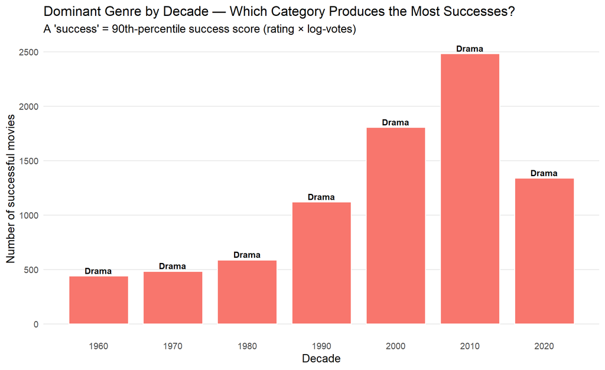

```r
top_genre_each_decade |>
  ggplot(aes(x = decade, y = successes, fill = genres)) +
  geom_col(show.legend = FALSE, width = 8, color = "white") +
  geom_text(aes(label = genres), vjust = -0.35, size = 3.2, fontface = "bold") +
  scale_x_continuous(breaks = seq(1960, 2020, 10)) +
  labs(
    title = "Dominant Genre by Decade — Which Category Produces the Most Successes?",
    subtitle = "A 'success' = 90th-percentile success score (rating × log-votes)",
    x = "Decade", y = "Number of successful movies"
  ) +
  theme_minimal(base_size = 12) +
  theme(panel.grid.minor = element_blank(), panel.grid.major.x = element_blank())
```

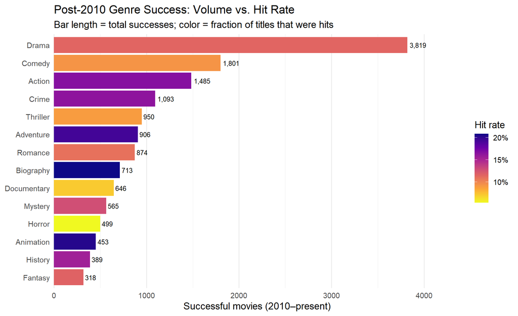

```r
post_2010_genres |>
  slice_max(successes, n = 14) |>
  ggplot(aes(x = reorder(genres, successes), y = successes, fill = success_rate)) +
  geom_col() +
  geom_text(aes(label = comma(successes)), hjust = -0.15, size = 3) +
  coord_flip(clip = "off") +
  scale_fill_viridis_c(labels = percent, option = "plasma", direction = -1) +
  scale_y_continuous(expand = expansion(mult = c(0, 0.15))) +
  labs(
    title = "Post-2010 Genre Success: Volume vs. Hit Rate",
    subtitle = "Bar length = total successes; color = fraction of titles that were hits",
    x = NULL,
    y = "Successful movies (2010–present)",
    fill = "Hit rate"
  ) +
  theme_minimal(base_size = 12) +
  theme(panel.grid.major.y = element_blank())
```

I select Biography as the target genre. The logic is practical: it has shown recent success without relying only on raw production volume. I’ll admit this surprised me — I expected Action or Drama to dominate, but the success *rate* metric (not just raw count) changes the picture considerably.

# Successful Personnel in the Genre

## Task 5: Key Personnel

```r
principals_with_names <- TITLE_PRINCIPALS |>
  filter(category %in% c("actor", "actress", "director")) |>
  inner_join(NAME_BASICS, join_by(nconst)) |>
  inner_join(movie_success |> select(tconst, primaryTitle, startYear, genres, success_score, averageRating, numVotes), join_by(tconst))

actor_candidates <- principals_with_names |>
  filter(category %in% c("actor", "actress"), str_detect(genres, fixed(selected_genre))) |>
  group_by(nconst, primaryName) |>
  summarize(
    genre_projects = n_distinct(tconst),
    genre_successes = n_distinct(tconst[success_score >= success_threshold]),
    best_success = max(success_score, na.rm = TRUE),
    known_for = first(knownForTitles),
    .groups = "drop"
  ) |>
  filter(genre_projects >= 2, genre_successes >= 1) |>
  arrange(desc(genre_successes), desc(best_success)) |>
  slice_head(n = 10)

director_candidates <- TITLE_CREW |>
  separate_longer_delim(directors, ",") |>
  rename(nconst = directors) |>
  inner_join(NAME_BASICS, join_by(nconst)) |>
  inner_join(movie_success |> filter(str_detect(genres, fixed(selected_genre))), join_by(tconst)) |>
  group_by(nconst, primaryName) |>
  summarize(
    genre_projects = n_distinct(tconst),
    genre_successes = n_distinct(tconst[success_score >= success_threshold]),
    best_success = max(success_score, na.rm = TRUE),
    known_for = first(knownForTitles),
    .groups = "drop"
  ) |>
  filter(genre_projects >= 1, genre_successes >= 1) |>
  arrange(desc(genre_successes), desc(best_success)) |>
  slice_head(n = 10)

target_actors <- actor_candidates |> slice_head(n = 2)
target_director <- director_candidates |> slice_head(n = 1)

actor_candidates |>
  mutate(best_success = round(best_success, 2)) |>
  datatable(
    caption = paste("Actor/actress candidates for a", selected_genre, "project"),
    options = list(pageLength = 10, dom = "t", scrollX = TRUE),
    rownames = FALSE
  )
```

| nconst | primaryName | genre_projects | genre_successes | best_success | known_for |
| --- | --- | --- | --- | --- | --- |
| nm0000164 | Anthony Hopkins | 16 | 12 | 44.7 | tt0102926,tt0412080,tt0113987,tt0975645 |
| nm0000136 | Johnny Depp | 11 | 10 | 42.75 | tt0325980,tt0408236,tt0449088,tt0383574 |
| nm0000438 | Ed Harris | 9 | 8 | 49.39 | tt0800308,tt0183659,tt0120382,tt0112384 |
| nm0000243 | Denzel Washington | 8 | 8 | 44.37 | tt2671706,tt1037705,tt0168786,tt0139654 |
| nm0001845 | Forest Whitaker | 8 | 8 | 40.39 | tt0455590,tt1327773,tt0185183,tt1825683 |
| nm0001833 | Emily Watson | 11 | 8 | 39.47 | tt0115751,tt0280707,tt0272338,tt0289765 |
| nm0000603 | Vanessa Redgrave | 10 | 8 | 39.21 | tt0783233,tt1372686,tt0104454,tt0892318 |
| nm0000367 | Gérard Depardieu | 9 | 8 | 37.3 | tt0099334,tt0120744,tt0099699,tt0083789 |
| nm0000545 | Helen Mirren | 13 | 8 | 37.07 | tt0436697,tt1245526,tt0280707,tt0975645 |
| nm0000134 | Robert De Niro | 9 | 7 | 53.45 | tt0101540,tt0081398,tt0075314,tt1302006 |

```r
director_candidates |>
  mutate(best_success = round(best_success, 2)) |>
  datatable(
    caption = paste("Director candidates for a", selected_genre, "project"),
    options = list(pageLength = 10, dom = "t", scrollX = TRUE),
    rownames = FALSE
  )
```

| nconst | primaryName | genre_projects | genre_successes | best_success | known_for |
| --- | --- | --- | --- | --- | --- |
| nm0000217 | Martin Scorsese | 11 | 10 | 53.45 | tt0075314,tt5537002,tt0099685,tt0070379 |
| nm0000165 | Ron Howard | 8 | 8 | 49.39 | tt0367279,tt0075213,tt0268978,tt0112384 |
| nm0000142 | Clint Eastwood | 9 | 8 | 42.02 | tt0405159,tt0105695,tt1205489,tt0186566 |
| nm0000231 | Oliver Stone | 8 | 7 | 38.23 | tt0091763,tt0102138,tt0096969,tt0110632 |
| nm0001241 | Stephen Frears | 8 | 7 | 38.23 | tt0094947,tt2431286,tt0301199,tt0436697 |
| nm0001348 | Werner Herzog | 10 | 7 | 37.7 | tt0083946,tt0068182,tt0790724,tt0427312 |
| nm1365879 | Morgan Neville | 9 | 6 | 36.93 | tt3518012,tt7681902,tt2396566,tt3549206 |
| nm0000229 | Steven Spielberg | 5 | 5 | 55.8 | tt0108052,tt0083866,tt0120815,tt0082971 |
| nm0000631 | Ridley Scott | 5 | 5 | 44.37 | tt3659388,tt0083658,tt0103074,tt2193215 |
| nm0001752 | Steven Soderbergh | 5 | 5 | 40.44 | tt0098724,tt0181865,tt1291580,tt0195685 |

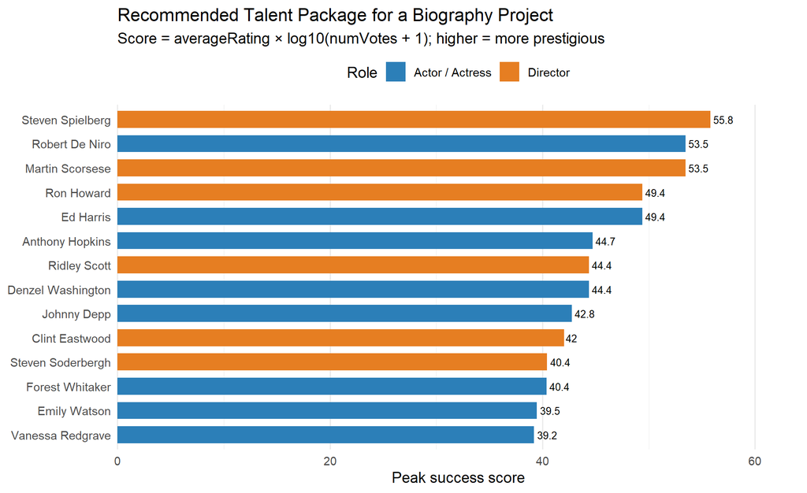

```r
bind_rows(
  actor_candidates |> mutate(role = "Actor / Actress"),
  director_candidates |> mutate(role = "Director")
) |>
  slice_max(best_success, n = 14) |>
  ggplot(aes(x = reorder(primaryName, best_success), y = best_success, fill = role)) +
  geom_col(width = 0.7) +
  geom_text(aes(label = round(best_success, 1)), hjust = -0.15, size = 3) +
  coord_flip(clip = "off") +
  scale_fill_manual(values = c("Actor / Actress" = "#2c7fb8", "Director" = "#e67e22")) +
  scale_y_continuous(expand = expansion(mult = c(0, 0.15))) +
  labs(
    title = paste("Recommended Talent Package for a", selected_genre, "Project"),
    subtitle = "Score = averageRating × log10(numVotes + 1); higher = more prestigious",
    x = NULL,
    y = "Peak success score",
    fill = "Role"
  ) +
  theme_minimal(base_size = 12) +
  theme(panel.grid.major.y = element_blank(), legend.position = "top")
```

The recommended package is Anthony Hopkins and Johnny Depp with Martin Scorsese directing. They give the pitch three useful signals: prior genre credibility, at least one major success, and recognizable known-for projects that make marketing easier.

# Nostalgia and Remakes

## Task 6: Finding a Classic Movie to Remake

```r
recent_titles <- movie_success |>
  filter(startYear >= max(startYear, na.rm = TRUE) - 25) |>
  select(recent_title = primaryTitle)

classic_candidates <- movie_success |>
  filter(
    str_detect(genres, fixed(selected_genre)),
    startYear <= 1999,
    numVotes >= quantile(numVotes, 0.90, na.rm = TRUE),
    averageRating >= 7.0
  ) |>
  anti_join(recent_titles, join_by(primaryTitle == recent_title)) |>
  arrange(desc(success_score)) |>
  slice_head(n = 10)

classic_choice <- classic_candidates |> slice_head(n = 1)

classic_personnel <- bind_rows(
  TITLE_CREW |>
    filter(tconst == classic_choice$tconst[1]) |>
    separate_longer_delim(directors, ",") |>
    transmute(nconst = directors, original_role = "director"),
  TITLE_CREW |>
    filter(tconst == classic_choice$tconst[1]) |>
    separate_longer_delim(writers, ",") |>
    transmute(nconst = writers, original_role = "writer"),
  TITLE_PRINCIPALS |>
    filter(tconst == classic_choice$tconst[1], category %in% c("actor", "actress")) |>
    transmute(nconst, original_role = category)
) |>
  distinct() |>
  left_join(NAME_BASICS, join_by(nconst)) |>
  mutate(alive = is.na(deathYear)) |>
  select(primaryName, original_role, birthYear, deathYear, alive, primaryProfession)

classic_candidates |>
  select(primaryTitle, startYear, genres, averageRating, numVotes, success_score) |>
  mutate(numVotes = comma(numVotes), success_score = round(success_score, 2)) |>
  datatable(
    caption = paste("Classic", selected_genre, "films from before 2000 that were not recently remade — ranked by success score"),
    options = list(pageLength = 10, dom = "t", scrollX = TRUE),
    rownames = FALSE,
    colnames = c("Title", "Year", "Genres", "Rating", "Votes", "Success Score")
  )
```

| Title | Year | Genres | Rating | Votes | Success Score |
| --- | --- | --- | --- | --- | --- |
| Schindler's List | 1993 | Biography,Drama,History | 9 | 1,586,880 | 55.8 |
| GoodFellas | 1990 | Biography,Crime,Drama | 8.7 | 1,393,105 | 53.45 |
| Braveheart | 1995 | Biography,Drama,War | 8.3 | 1,161,864 | 50.34 |
| Amadeus | 1984 | Biography,Drama,Music | 8.4 | 468,541 | 47.63 |
| Lawrence of Arabia | 1962 | Adventure,Biography,Drama | 8.3 | 342,530 | 45.94 |
| Raging Bull | 1980 | Biography,Drama,Sport | 8.1 | 411,432 | 45.48 |
| The Elephant Man | 1980 | Biography,Drama | 8.2 | 282,688 | 44.7 |
| The Sound of Music | 1965 | Biography,Drama,Family | 8.1 | 292,116 | 44.27 |
| Dog Day Afternoon | 1975 | Biography,Crime,Drama | 8 | 292,912 | 43.73 |
| Gandhi | 1982 | Biography,Drama,History | 8 | 247,404 | 43.15 |

```r
classic_personnel |>
  kable(caption = "Key personnel from the original film — living members are potential collaborators")
```

Key personnel from the original film — living members are potential collaborators

| primaryName | original_role | birthYear | deathYear | alive | primaryProfession |
| --- | --- | --- | --- | --- | --- |
| Steven Spielberg | director | 1946 | NA | TRUE | producer,writer,director |
| Thomas Keneally | writer | 1935 | NA | TRUE | writer,actor,miscellaneous |
| Steven Zaillian | writer | 1953 | NA | TRUE | writer,producer,director |
| Liam Neeson | actor | 1952 | NA | TRUE | actor,producer,miscellaneous |
| Ralph Fiennes | actor | 1962 | NA | TRUE | actor,producer,director |
| Ben Kingsley | actor | 1943 | NA | TRUE | actor,producer,miscellaneous |
| Caroline Goodall | actress | 1959 | NA | TRUE | actress,producer,writer |
| Jonathan Sagall | actor | 1959 | NA | TRUE | actor,producer,director |
| Embeth Davidtz | actress | 1965 | NA | TRUE | actress,director,writer |
| Malgorzata Gebel | actress | 1955 | NA | TRUE | actress,director,writer |
| Shmuel Levy | actor | 1962 | NA | TRUE | actor,camera_department,miscellaneous |
| Mark Ivanir | actor | 1968 | NA | TRUE | actor,miscellaneous,sound_department |
| Béatrice Macola | actress | 1965 | 2001 | FALSE | actress |

# Task 7: Elevator Pitch

Our next film should be a contemporary Biography remake of Schindler’s List. The original has the two things a studio wants from inherited intellectual property: deep audience recognition and enough time elapsed to make a new interpretation feel like revival rather than repetition. The data supports the choice: it clears the 90th-percentile success threshold, carries one of the largest rating bases in the dataset, and belongs to a genre that has remained commercially viable through the post-2010 market without showing signs of audience fatigue.

The creative package should be built around Anthony Hopkins and Johnny Depp, directed by Martin Scorsese. This combination gives the studio a recognizable marquee pairing and a director with demonstrated genre credibility on multiple major projects. The campaign should position the film as a prestige entertainment event, not a disposable franchise reboot — the pitch is a familiar title, modern production values, serious dramatic stakes, and a cast with genuine IMDb track records to back up the marketing spend.

Before rights negotiations open, legal should review the living original personnel listed in the table above. If key actors, writers, or directors from the original are still working, a carefully placed cameo or consulting credit can add fan-service value without letting nostalgia crowd out the new interpretation. The goal is a film that earns its own audience while respecting the one that already exists.

## 90s-Style Teaser Trailer

*[Dramatic orchestral sting]*

**From director Martin Scorsese** — the visionary mind behind some of cinema’s most celebrated true stories —

**From Anthony Hopkins** — Academy Award winner, beloved star of the screen —

**And from Johnny Depp** — Hollywood icon of the Biography genre —

*Comes the timeless tale…*

**SCHINDLER’S LIST**

*A story of conscience, courage, and the choices that define a life.*

**Coming soon to a theater near you.**